# Self-reported expressibility predicts communicative success: Open dataset, validation, and simulation

# 5 Hypothesis 1: Expressibility vs. guessability

*The higher the expressibility rating of the concept for the modality in which the concept is produced, the higher the guessability will be.*

## 5.1 Guess binary

Preregistered model:

`guessability_match ~ expressibility + (1 | dyad/participant) + (1 | concept), family = bernoulli(link='logit')`

```r
mdl_H1_binary <- readRDS(paste0(models, "mdl_H1_binary.rds"))
```

Calculate R².

```
##     Estimate   Est.Error     Q2.5     Q97.5
## R2 0.3178249 0.006357378 0.305054 0.3299844
```

R^2 is 0.3178249 suggesting that 31.7824856% of the variance in the outcome variable are explained by the model.

**Diagnostic plots**:

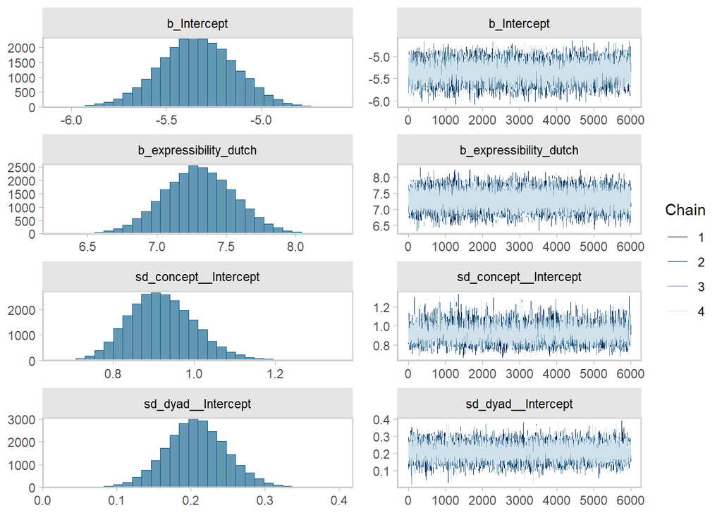

```r
plot(mdl_H1_binary)
```

**Convergence**: All convergence diagnostics are excellent (Rhat = 1.00).

```r
summary(mdl_H1_binary)
```

```
##  Family: bernoulli
##   Links: mu = logit
## Formula: guess_binary ~ expressibility_dutch + (1 | dyad) + (1 | concept)
##    Data: df (Number of observations: 8989)
##   Draws: 4 chains, each with iter = 10000; warmup = 4000; thin = 1;
##          total post-warmup draws = 24000
##
## Multilevel Hyperparameters:
## ~concept (Number of levels: 84)
##               Estimate Est.Error l-95% CI u-95% CI Rhat Bulk_ESS Tail_ESS
## sd(Intercept)     0.92      0.08     0.77     1.10 1.00     4261     8457
##
## ~dyad (Number of levels: 71)
##               Estimate Est.Error l-95% CI u-95% CI Rhat Bulk_ESS Tail_ESS
## sd(Intercept)     0.21      0.04     0.13     0.29 1.00     9621    11078
##
## Regression Coefficients:
##                      Estimate Est.Error l-95% CI u-95% CI Rhat Bulk_ESS
## Intercept               -5.34      0.20    -5.73    -4.95 1.00     6964
## expressibility_dutch     7.30      0.26     6.80     7.81 1.00    20433
##                      Tail_ESS
## Intercept               13795
## expressibility_dutch    19137
##
## Draws were sampled using sampling(NUTS). For each parameter, Bulk_ESS
## and Tail_ESS are effective sample size measures, and Rhat is the potential
## scale reduction factor on split chains (at convergence, Rhat = 1).
```

```
## No divergences to plot.
```

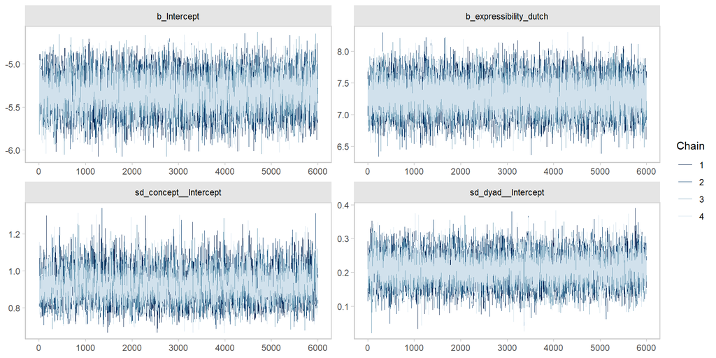

**Figure 17.** Trace of the fitting process. Figure generated using [`R`](https://www.r-project.org/) version 4.4.1 (2024-06-14 ucrt)

```r
mcmc_plot(mdl_H1_binary, type="trace");
```

**Posterior predictive checks**: Looking good.

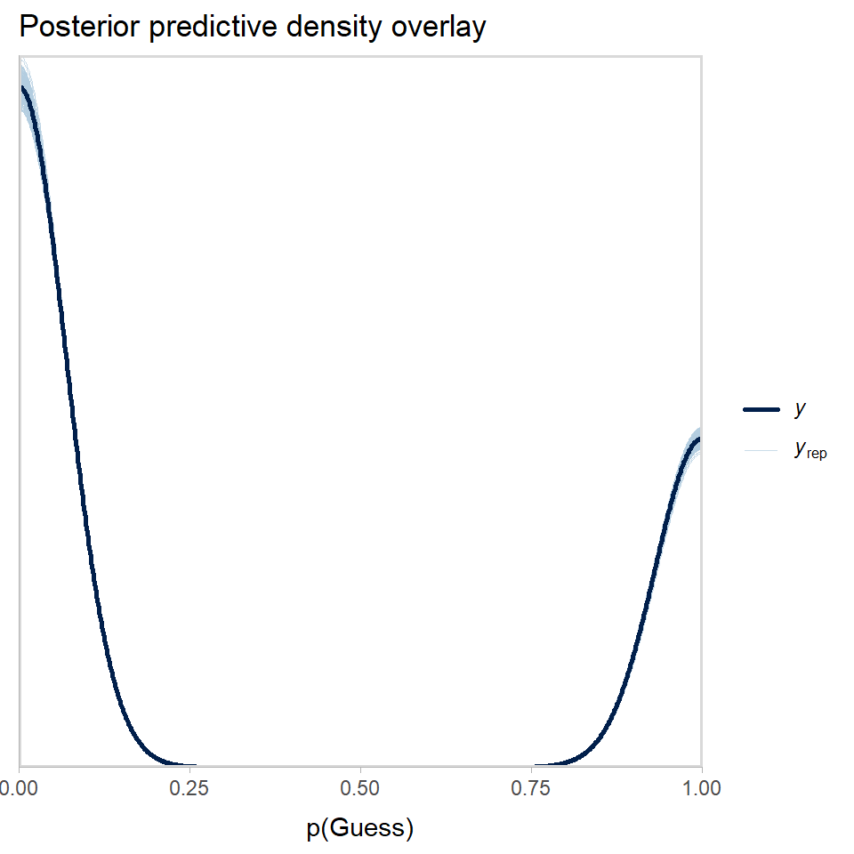

**Figure 18.** Posterior predictive density overlay for n=500 draws. Figure generated using [`R`](https://www.r-project.org/) version 4.4.1 (2024-06-14 ucrt)

```r
pp_check(mdl_H1_binary, ndraws=500) + xlab('p(Guess)') + ggtitle('Posterior predictive density overlay');
```

```
## Using all posterior draws for ppc type 'stat' by default.
## Using all posterior draws for ppc type 'stat' by default.
## Using all posterior draws for ppc type 'stat' by default.
```

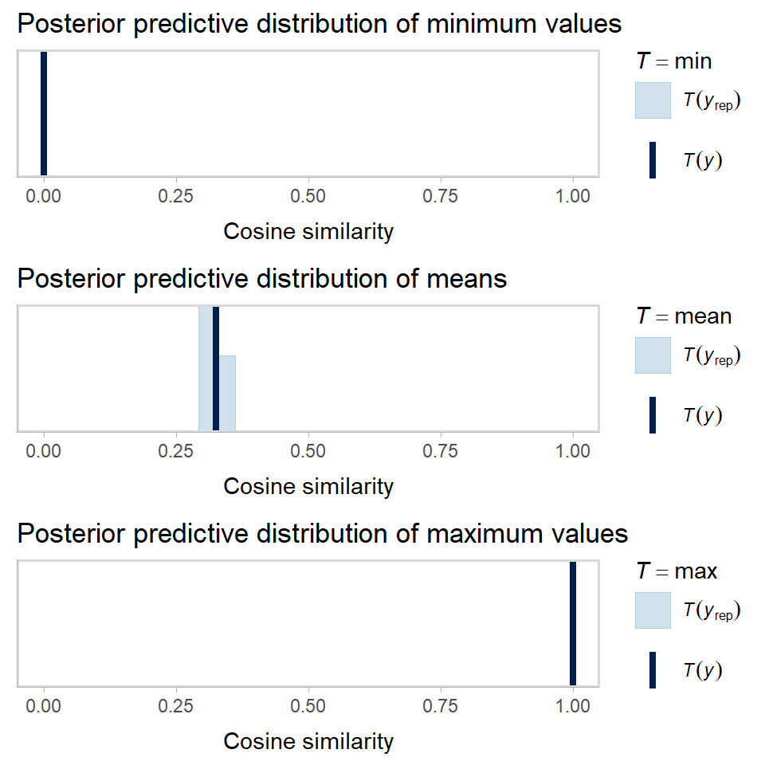

**Figure 19.** Posterior predictive distribution. Figure generated using [`R`](https://www.r-project.org/) version 4.4.1 (2024-06-14 ucrt)

```r
grid.arrange(pp_check(mdl_H1_binary, type='stat', sta ='min') + xlab('Cosine similarity') + ggtitle('Posterior predictive distribution of minimum values') + xlim(0,1),
             pp_check(mdl_H1_binary, type='stat', stat='mean') + xlab('Cosine similarity') + ggtitle('Posterior predictive distribution of means') + xlim(0,1),
             pp_check(mdl_H1_binary, type='stat', stat='max') + xlab('Cosine similarity') + ggtitle('Posterior predictive distribution of maximum values') + xlim(0,1),
             ncol=1);
```

**Fixed effects**:

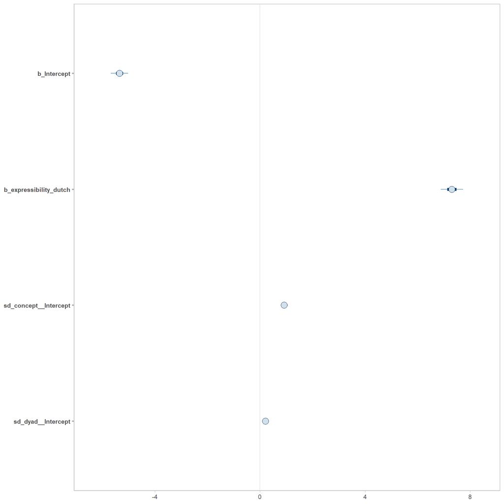

**Figure 20.** Fixed effects’ posterior distributions. Figure generated using [`R`](https://www.r-project.org/) version 4.4.1 (2024-06-14 ucrt)

```r
mcmc_plot(mdl_H1_binary);
```

```
## Data were 'prettified'. Consider using `terms="expressibility_dutch
##   [all]"` to get smooth plots.
```

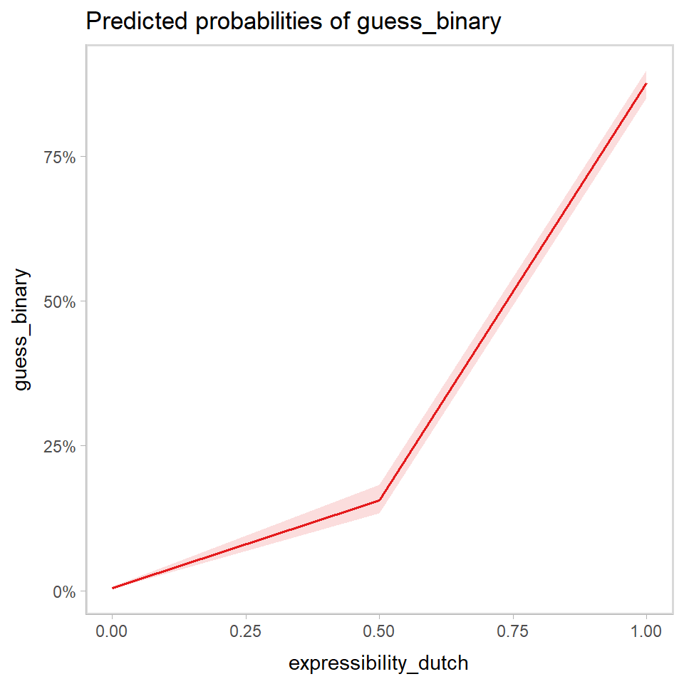

**Figure 21.** Fixed effects. Figure generated using [`R`](https://www.r-project.org/) version 4.4.1 (2024-06-14 ucrt)

```r
plot_model(mdl_H1_binary, type="emm", terms=c("expressibility_dutch"));
```

```r
# because of the logit link, it needs to be backtransformed
emmeans(mdl_H1_binary, ~ expressibility_dutch, type = "response")
```

```
##  expressibility_dutch response lower.HPD upper.HPD
##                 0.595     0.27     0.229     0.313
##
## Point estimate displayed: median
## Results are back-transformed from the logit scale
## HPD interval probability: 0.95
```

```r
bayestestR::hdi(mdl_H1_binary, ci=0.95)
```

|  | Parameter | CI | CI_low | CI_high | Effects | Component |
| --- | --- | --- | --- | --- | --- | --- |
| 2 | b_Intercept | 0.95 | -5.735764 | -4.951443 | fixed | conditional |
| 1 | b_expressibility_dutch | 0.95 | 6.806957 | 7.810618 | fixed | conditional |

```r
hypothesis(mdl_H1_binary, c("(expressibility_dutch) > 0"))
```

```
## Hypothesis Tests for class b:
##                 Hypothesis Estimate Est.Error CI.Lower CI.Upper Evid.Ratio
## 1 ((expressibility_... > 0      7.3      0.26     6.88     7.73        Inf
##   Post.Prob Star
## 1         1    *
## ---
## 'CI': 90%-CI for one-sided and 95%-CI for two-sided hypotheses.
## '*': For one-sided hypotheses, the posterior probability exceeds 95%;
## for two-sided hypotheses, the value tested against lies outside the 95%-CI.
## Posterior probabilities of point hypotheses assume equal prior probabilities.
```

**Intercept**: The intercept is -5.34 95%CI [-5.73, -4.95] on the log odds ratio (LOR) scale. When we convert this value using the inverse‐logit transformation, it corresponds to an overall predicted probability of a correct guess of 0.5% 95%CI [0.3%, 0.7%] when expressibility_dutch equals 0. However, since expressibility_dutch is not centered and its average in our data is approximately 0.595, the effective intercept at the average expressibility is -1.00, which back–transforms to an overall predicted probability of about 27.0%.

**Expressibility**: The slope for expressibility_dutch is 7.30 95%CI [6.80, 7.81] on the LOR scale. This implies that for every one–unit increase in expressibility_dutch the odds of a correct guess are multiplied by 1483.

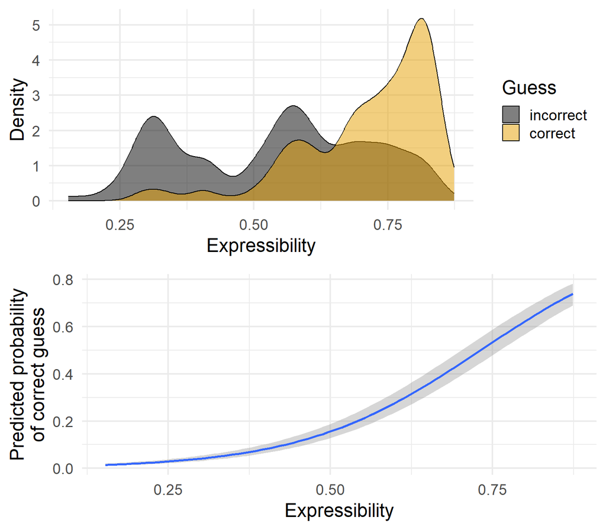

**Figure 22.** Top: Observed density of expressibility (Dutch) for each guess outcome. The black curve corresponds to observations with incorrect guesses, while the yellow curve corresponds to correct guesses. Bottom: Model-predicted probability of a correct guess as a function of expressibility. The plot shows the median predicted probability along with uncertainty bands, illustrating that higher expressibility is associated with a substantially increased probability of a correct guess. Figure generated using [`R`](https://www.r-project.org/) version 4.4.1 (2024-06-14 ucrt)

```r
# Panel 1: Observed distribution of expressibility_dutch by guess outcome
p_obs <- df %>%
  filter(!is.na(guess_binary)) %>%
  ggplot(aes(x = expressibility_dutch, fill = factor(guess_binary))) +
  geom_density(alpha = 0.5) +
  scale_fill_manual(values = c("0" = colorBlindBlack8[1], "1" = colorBlindBlack8[2]),
                    labels = c("incorrect", "correct")) +
  labs(x = "Expressibility", y = "Density", fill = "Guess") +
  theme_minimal(base_size = 18)

# Panel 2: Conditional effects of expressibility_dutch on predicted probability
ce_exp <- conditional_effects(mdl_H1_binary, effects = "expressibility_dutch")
p_pred <- plot(ce_exp, plot = FALSE)[[1]] +
  labs(x = "Expressibility", y = "Predicted probability\nof correct guess") +
  theme_minimal(base_size = 18)

# Arrange the two panels vertically using grid.arrange
grid.arrange(p_obs, p_pred, ncol = 1)
```

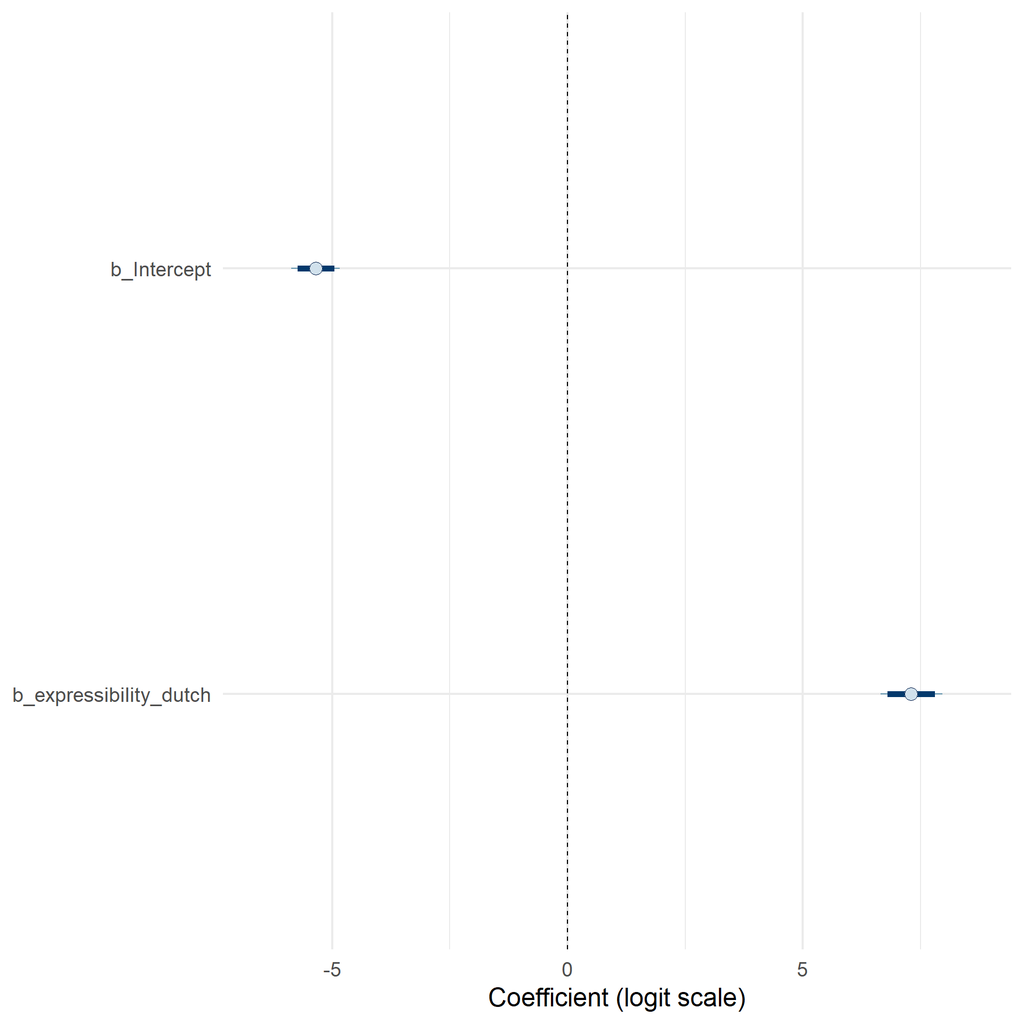

**Figure 23.** Posterior draws for the fixed effects. Figure generated using [`R`](https://www.r-project.org/) version 4.4.1 (2024-06-14 ucrt)

```r
# Extract posterior draws for the fixed effects
# For our binary model, the coefficients are on the logit scale.
posterior_fixed <- as.matrix(mdl_H1_binary, variable = c("b_Intercept", "b_expressibility_dutch"))

# Plot using mcmc_intervals; we add a dashed vertical line at 0 for reference.
mcmc_intervals(posterior_fixed, prob = 0.95, prob_outer = 0.99) +
  geom_vline(xintercept = 0, linetype = "dashed") +
  labs(
    x = "Coefficient (logit scale)"
  ) +
  theme_minimal(base_size = 18)
```

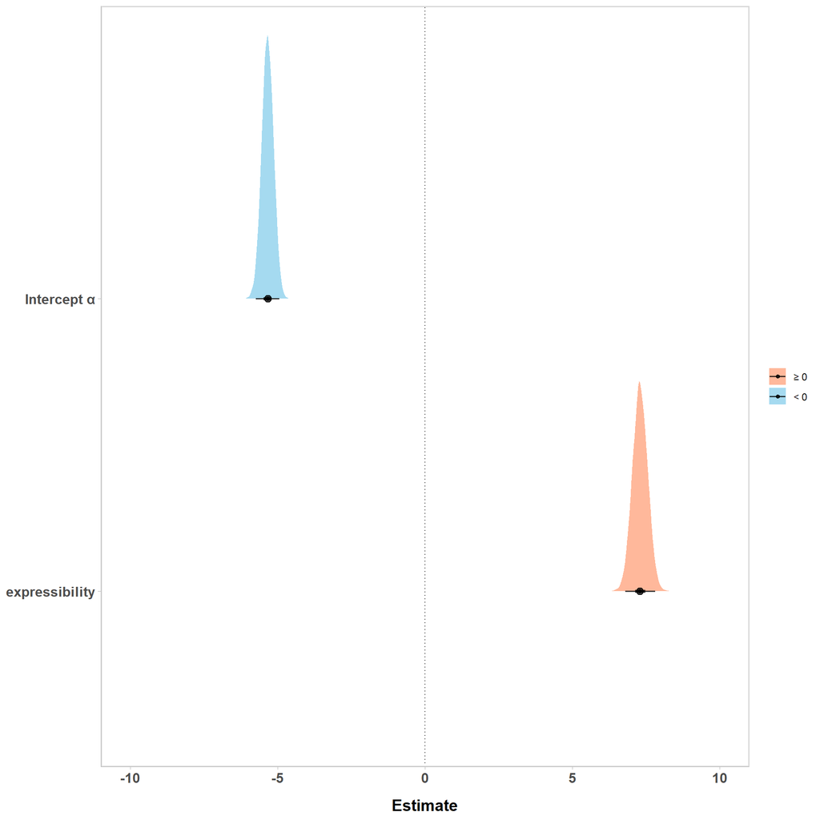

**Figure 24.** Posterior estimates of the fixed effects showing the median (dot), 50% (thick line) and 95% (thin lines) quantiles. Also showing 0 as the vertical dotted line and negative (blue) vs positive (red) values. Figure generated using [`R`](https://www.r-project.org/) version 4.4.1 (2024-06-14 ucrt)

```r
gather_draws(mdl_H1_binary, `b_.*`, regex = TRUE) %>%
    # remove the b_ for plotting
    #mutate(.variable = gsub("b_","", .variable)) %>%
    ggplot(aes(x = .value, y = .variable, fill = after_stat(x < 0))) +
    geom_vline(xintercept=0.0, linetype="dotted", color="gray30") +
    stat_halfeye(alpha=0.75, point_interval=median_qi, .width=c(.50, .95)) +
    scale_fill_manual(values = c("lightsalmon", "skyblue"), name=NULL, labels=c("≥ 0", "< 0")) +
    xlim(-10, 10) +
    scale_y_discrete(labels=c("b_Intercept" = "Intercept α",
                              "b_expressibility_dutch" = "expressibility")) +
    ylab(NULL) + xlab("Estimate") +
    theme(axis.title.x = element_text(margin = margin(t = 12, b = 0,
                                                      r = 0, l = 0),
                                      face = 'bold', size = 14),
          axis.text.x = element_text(face = 'bold', size = 12),
          axis.text.y = element_text(face = 'bold', size = 12))
```

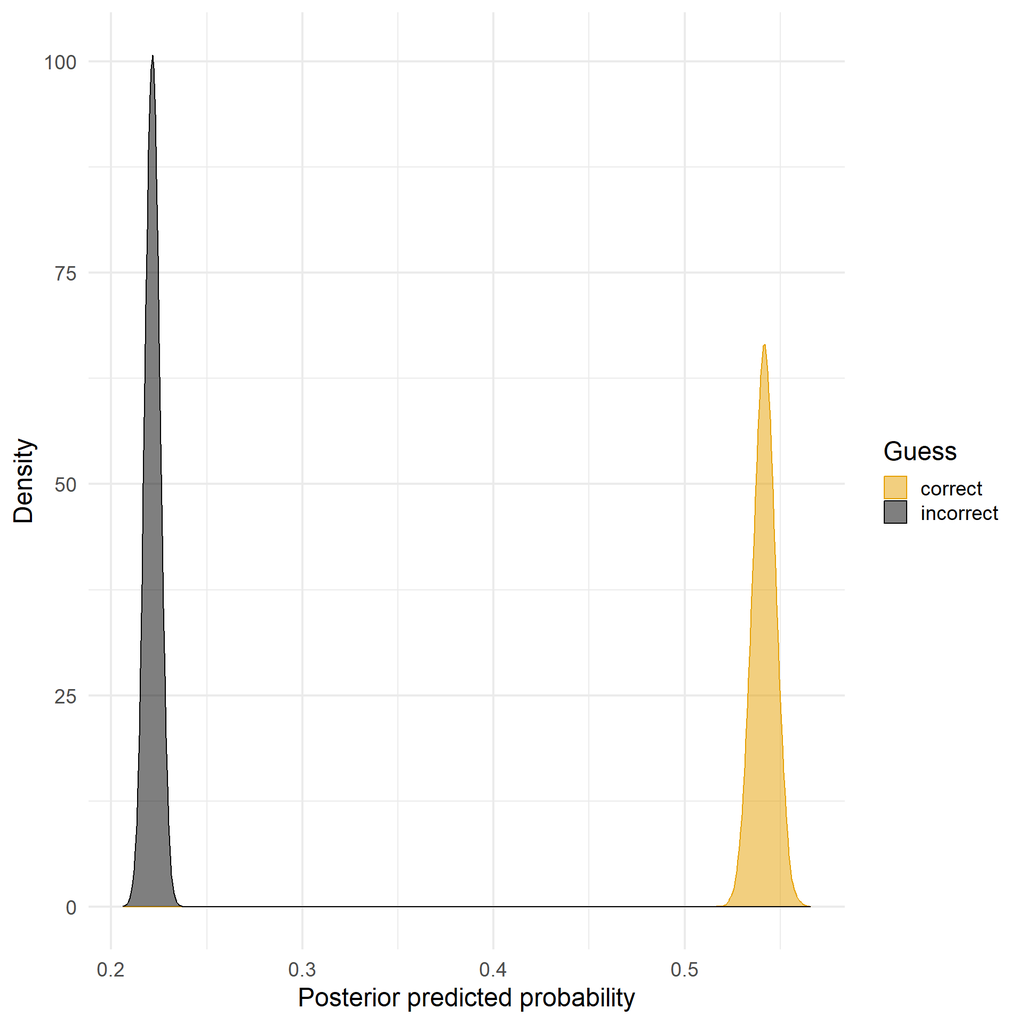

```r
# Extract posterior predictions on the response scale (matrix: draws x observations)
epred_matrix <- posterior_epred(mdl_H1_binary, type = "response")

# Convert guess_binary to numeric 0/1 (if not already)
df <- df %>% mutate(guess_binary_num = as.numeric(as.character(guess_binary)))

# Identify indices for each outcome group
idx_incorrect <- which(df$guess_binary_num == 0)
idx_correct   <- which(df$guess_binary_num == 1)

# For each posterior draw, compute the mean predicted probability for each group
mean_pred_incorrect <- apply(epred_matrix[, idx_incorrect, drop = FALSE], 1, mean)
mean_pred_correct   <- apply(epred_matrix[, idx_correct, drop = FALSE], 1, mean)

# Build a tidy data frame
df_post <- tibble(
  guess = rep(c("incorrect", "correct"), each = length(mean_pred_incorrect)),
  mean_pred = c(mean_pred_incorrect, mean_pred_correct)
)

# Plot the density of these aggregated predictions
ggplot(df_post, aes(x = mean_pred, fill = guess, color = guess)) +
  geom_density(alpha = 0.5, adjust = 1.2) +
  scale_fill_manual(values = c("incorrect" = colorBlindBlack8[1], "correct" = colorBlindBlack8[2])) +
  scale_color_manual(values = c("incorrect" = colorBlindBlack8[1], "correct" = colorBlindBlack8[2])) +
  labs(
    x = "Posterior predicted probability",
    y = "Density",
    #title = "Aggregated posterior predictions by outcome group",
    fill = "Guess", color = "Guess"
  ) +
  theme_minimal(base_size = 18)
```

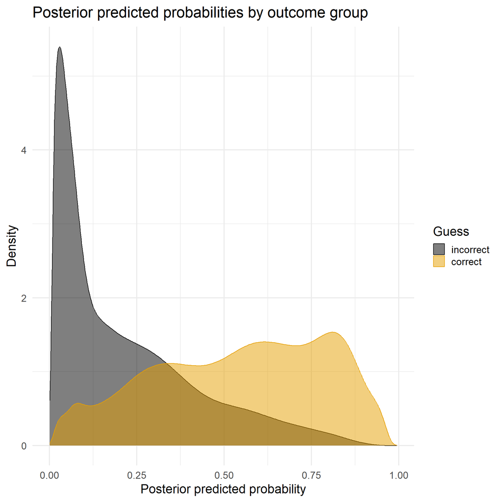

**Figure 26.** Posterior predicted probabilities by outcome group. This density plot is based on individual-level predictions (or a random subset thereof), stratified by guess outcome. The plot shows that predictions for incorrect guesses are tightly concentrated near 0, while predictions for correct guesses are more variable and generally higher, reflecting the model’s ability to distinguish between the two outcomes. Figure generated using [`R`](https://www.r-project.org/) version 4.4.1 (2024-06-14 ucrt)

```r
# # Take a random subset of the data (e.g., 500 observations)
# df_subset <- df %>%
#   filter(!is.na(guess_binary)) %>%
#   sample_n(500)

# Extract posterior draws of the predicted probability for these observations
# The plot takes a while, so if you just need a general overview, use the code above to just take a sample
#df_subset %>%
df %>%
  add_epred_draws(mdl_H1_binary, type = "response") %>%
  ggplot(aes(x = .epred, fill = factor(guess_binary), color = factor(guess_binary))) +
  geom_density(alpha = 0.5, adjust = 1.2) +
  scale_fill_manual(values = c("0" = colorBlindBlack8[1], "1" = colorBlindBlack8[2]),
                    labels = c("incorrect", "correct")) +
  scale_color_manual(values = c("0" = colorBlindBlack8[1], "1" = colorBlindBlack8[2]),
                     labels = c("incorrect", "correct")) +
  labs(
    x = "Posterior predicted probability",
    y = "Density",
    title = "Posterior predicted probabilities by outcome group",
    fill = "Guess", color = "Guess"
  ) +
  theme_minimal(base_size = 18)
```

```r
# ggsave(plot = last_plot(), filename = paste0(plots, "mdl_H1_binary_postByOutcome.pdf"), width = 6, height = 6);
# ggsave(plot = last_plot(), filename = paste0(plots, "mdl_H1_binary_postByOutcome.jpg"), width = 6, height = 6);
# ggsave(plot = last_plot(), filename = paste0(plots, "mdl_H1_binary_postByOutcome.tif"), width = 6, height = 6, compression="lzw", dpi=600);
```

In this plot, the model’s posterior predicted probability is extracted for each individual observation (or for a randomly selected subset). The density curves are then constructed based on these individual-level predictions, separately for observations that are actually incorrect versus correct. Here, you will typically see that the distribution for incorrect guesses is highly concentrated near 0, indicating that most individual predictions for the incorrect group are very low. On the other hand, the distribution for correct guesses is more spread out, showing more variability in the predicted probabilities. This plot therefore reveals not only the overall difference between the two groups but also the within-group variation in predictions.